# Production Efficiency, Quality, and Sales Performance Analysis of AutoDrive Motors Ltd. Using Python

## Manufacturing Analytics Assignment

Step 1: Import Libraries

```python
# Import Required Libraries

import pandas as pd
import numpy as np
import matplotlib.pyplot as plt
import seaborn as sns

# Display charts neatly
plt.style.use('ggplot')

# Ignore warnings
import warnings
warnings.filterwarnings('ignore')
```

## Load Dataset

```python
# Load Dataset

df = pd.read_csv("AutoDrive_Motors_Manufacturing_Dataset_1200.csv")

# Display first five rows
df.head()
```

|  | Production_ID | Date | Month | Year | Plant | Vehicle_Type | Shift | Units_Produced | Production_Cost | Defects | Defect_Rate | Inspection_Score | Warranty_Claims | Sales | Efficiency |
| --- | --- | --- | --- | --- | --- | --- | --- | --- | --- | --- | --- | --- | --- | --- | --- |
| 0 | PD0001 | 2025-10-16 | October | 2025 | Plant A | Commercial Vehicle | Morning | 1464 | 1509570 | 12 | 0.82 | 95 | 8 | 1399 | 95.56 |
| 1 | PD0002 | 2025-08-27 | August | 2025 | Plant B | Passenger Vehicle | Morning | 1319 | 794254 | 20 | 1.52 | 94 | 9 | 1197 | 90.75 |
| 2 | PD0003 | 2025-12-19 | December | 2025 | Plant B | Passenger Vehicle | Night | 1342 | 583707 | 22 | 1.64 | 90 | 14 | 1259 | 93.82 |
| 3 | PD0004 | 2024-10-11 | October | 2024 | Plant A | Commercial Vehicle | Evening | 1402 | 1176417 | 9 | 0.64 | 94 | 6 | 1283 | 91.51 |
| 4 | PD0005 | 2024-09-27 | September | 2024 | Plant D | Commercial Vehicle | Night | 863 | 1107419 | 27 | 3.13 | 82 | 18 | 792 | 91.77 |

Step 3: Dataset Information

```python
# Dataset Shape

print("Number of Rows and Columns:")
print(df.shape)
```

```
Number of Rows and Columns:
(1200, 15)
```

Interpretation This dataset contains 1200 records with 15 columns.

It provides manufacturing, quality, and sales information for AutoDrive Motors Ltd.

The dataset size is sufficient for performing exploratory data analysis and manufacturing analytics.

## Data Preparation

```python
print("Shape:", df.shape)
print("--------------------------------------------------------------------------")
print("\nMissing Values")
print(df.isnull().sum())
print("--------------------------------------------------------------------------")

print("\nDuplicate Rows:", df.duplicated().sum())
print("--------------------------------------------------------------------------")

df.info()
print("--------------------------------------------------------------------------")
df.describe()
```

```
Shape: (1200, 15)
--------------------------------------------------------------------------

Missing Values
Production_ID       0
Date                0
Month               0
Year                0
Plant               0
Vehicle_Type        0
Shift               0
Units_Produced      0
Production_Cost     0
Defects             0
Defect_Rate         0
Inspection_Score    0
Warranty_Claims     0
Sales               0
Efficiency          0
dtype: int64
--------------------------------------------------------------------------

Duplicate Rows: 0
--------------------------------------------------------------------------
<class 'pandas.core.frame.DataFrame'>
RangeIndex: 1200 entries, 0 to 1199
Data columns (total 15 columns):
 #   Column            Non-Null Count  Dtype
---  ------            --------------  -----
 0   Production_ID     1200 non-null   object
 1   Date              1200 non-null   object
 2   Month             1200 non-null   object
 3   Year              1200 non-null   int64
 4   Plant             1200 non-null   object
 5   Vehicle_Type      1200 non-null   object
 6   Shift             1200 non-null   object
 7   Units_Produced    1200 non-null   int64
 8   Production_Cost   1200 non-null   int64
 9   Defects           1200 non-null   int64
 10  Defect_Rate       1200 non-null   float64
 11  Inspection_Score  1200 non-null   int64
 12  Warranty_Claims   1200 non-null   int64
 13  Sales             1200 non-null   int64
 14  Efficiency        1200 non-null   float64
dtypes: float64(2), int64(7), object(6)
memory usage: 140.8+ KB
--------------------------------------------------------------------------
```

|  | Year | Units_Produced | Production_Cost | Defects | Defect_Rate | Inspection_Score | Warranty_Claims | Sales | Efficiency |
| --- | --- | --- | --- | --- | --- | --- | --- | --- | --- |
| count | 1200.000000 | 1200.000000 | 1.200000e+03 | 1200.000000 | 1200.000000 | 1200.000000 | 1200.000000 | 1200.000000 | 1200.000000 |
| mean | 2024.525000 | 1295.387500 | 8.798548e+05 | 23.245000 | 1.979300 | 89.785000 | 12.998333 | 1199.144167 | 92.549708 |
| std | 0.499583 | 226.152924 | 3.292478e+05 | 11.524929 | 1.252151 | 6.324063 | 7.319926 | 213.507692 | 2.596282 |
| min | 2024.000000 | 800.000000 | 5.007140e+05 | 5.000000 | 0.370000 | 76.000000 | 2.000000 | 714.000000 | 88.010000 |
| 25% | 2024.000000 | 1117.750000 | 6.459600e+05 | 14.000000 | 0.920000 | 85.000000 | 7.000000 | 1029.750000 | 90.337500 |
| 50% | 2025.000000 | 1319.000000 | 7.900865e+05 | 22.000000 | 1.610000 | 91.000000 | 11.500000 | 1217.000000 | 92.445000 |
| 75% | 2025.000000 | 1470.000000 | 9.454748e+05 | 31.000000 | 2.775000 | 95.000000 | 17.000000 | 1368.000000 | 94.782500 |
| max | 2025.000000 | 1700.000000 | 1.794115e+06 | 56.000000 | 4.990000 | 99.000000 | 37.000000 | 1639.000000 | 97.070000 |

## Exploratory Data Analysis (EDA)

Chart 1: Production Distribution Across Manufacturing Plants

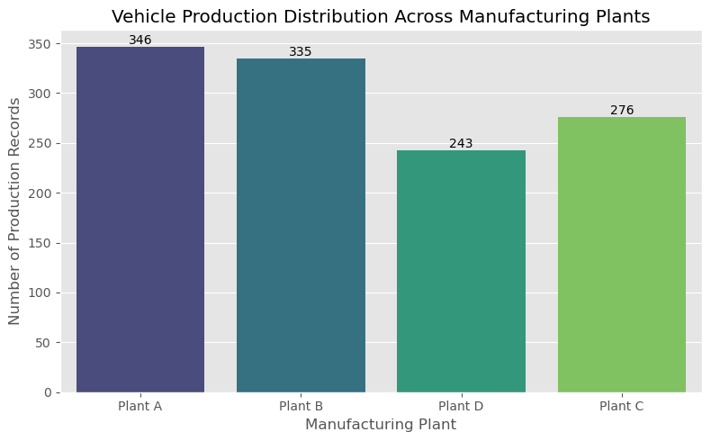

```python
plt.figure(figsize=(8,5))

ax = sns.countplot(
    data=df,
    x='Plant',
    palette='viridis'
)

plt.title("Vehicle Production Distribution Across Manufacturing Plants")
plt.xlabel("Manufacturing Plant")
plt.ylabel("Number of Production Records")

# Value Labels
for container in ax.containers:
    ax.bar_label(container, fontsize=10)

plt.tight_layout()
plt.show()
```

Interpretation:

Plant A produced 346 records.

Plant B produced 335 records.

Plant A has the highest production, indicating greater manufacturing capacity or higher production allocation.

Chart 2: Vehicle Category Distribution

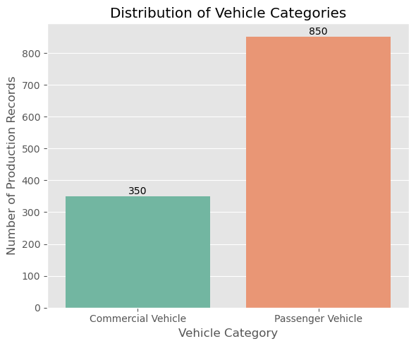

```python
plt.figure(figsize=(6,5))

ax = sns.countplot(
    data=df,
    x='Vehicle_Type',
    palette='Set2'
)

plt.title("Distribution of Vehicle Categories")
plt.xlabel("Vehicle Category")
plt.ylabel("Number of Production Records")

for container in ax.containers:
    ax.bar_label(container, fontsize=10)

plt.tight_layout()
plt.show()
```

Interpretation

Passenger Vehicles (PV): 850

Commercial Vehicles (CV): 350

Chart 3: Production Cost Distribution

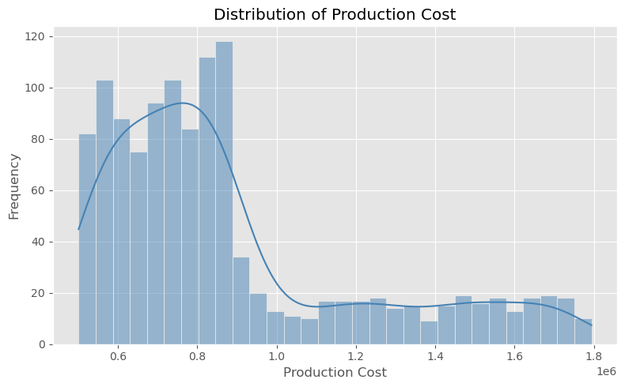

```python
plt.figure(figsize=(8,5))

sns.histplot(
    df['Production_Cost'],
    bins=30,
    kde=True,
    color='steelblue'
)

plt.title("Distribution of Production Cost")
plt.xlabel("Production Cost")
plt.ylabel("Frequency")

plt.tight_layout()
plt.show()
```

Interpretation:

The histogram shows how production costs are distributed.

A normal-shaped curve indicates that production costs are consistent across manufacturing operations.

Any extreme values may indicate unusually high or low production costs.

Chart 4: Defect Rate Distribution

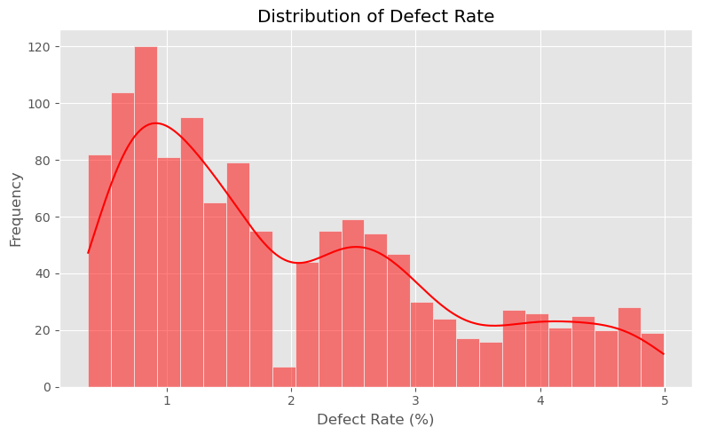

```python
plt.figure(figsize=(8,5))

sns.histplot(
    df['Defect_Rate'],
    bins=25,
    kde=True,
    color='red'
)

plt.title("Distribution of Defect Rate")
plt.xlabel("Defect Rate (%)")
plt.ylabel("Frequency")

plt.tight_layout()
plt.show()
```

Interpretation:

This chart shows how defect rates vary across production batches.

Most observations concentrated at lower defect rates indicate effective quality control.

Higher defect rates should be investigated to identify manufacturing issues.

Chart 5: Sales Distribution

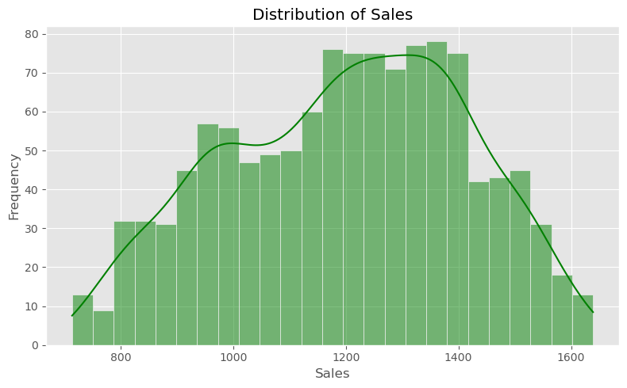

```python
plt.figure(figsize=(8,5))

sns.histplot(
    df['Sales'],
    bins=25,
    kde=True,
    color='green'
)

plt.title("Distribution of Sales")
plt.xlabel("Sales")
plt.ylabel("Frequency")

plt.tight_layout()
plt.show()
```

Interpretation:

The sales distribution indicates the frequency of different sales volumes.

A balanced distribution suggests stable sales performance.

Peaks in the histogram represent the most common sales ranges achieved by the company.

## Plant-wise Production Analysis

Objective:

Compare vehicle production across manufacturing plants.

Calculate production efficiency.

Compare production cost.

Identify the best-performing manufacturing plant.

Analysis 1: Total Units Produced by Each Plant

```python
# Total Units Produced by Plant

plant_production = df.groupby('Plant')['Units_Produced'].sum().reset_index()

print(plant_production)
```

```
     Plant  Units_Produced
0  Plant A          530214
1  Plant B          459319
2  Plant C          326340
3  Plant D          238592
```

Interpretation:

The above table shows the total number of vehicles produced by each manufacturing plant. The plant with the highest production contributes the most to the company's overall manufacturing output, while the plant with the lowest production may require capacity improvement or resource optimization.

Visualization: Total Units Produced by Plant

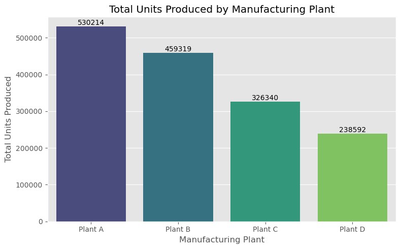

```python
plt.figure(figsize=(8,5))

ax = sns.barplot(
    data=plant_production,
    x='Plant',
    y='Units_Produced',
    palette='viridis'
)

plt.title("Total Units Produced by Manufacturing Plant")
plt.xlabel("Manufacturing Plant")
plt.ylabel("Total Units Produced")

# Add Value Labels
for container in ax.containers:
    ax.bar_label(container, fmt='%.0f', fontsize=10)

plt.tight_layout()
plt.show()
```

Interpretation:

Analysis 2: Average Production Efficiency by Plant

```python
plant_efficiency = df.groupby('Plant')['Efficiency'].mean().reset_index()

print(plant_efficiency)
```

```
     Plant  Efficiency
0  Plant A   92.660549
1  Plant B   92.632299
2  Plant C   92.403152
3  Plant D   92.444486
```

Interpretation:

This table presents the average production efficiency of each manufacturing plant. Higher efficiency indicates better utilization of resources, reduced waste, and improved production performance.

Visualization: Average Production Efficiency

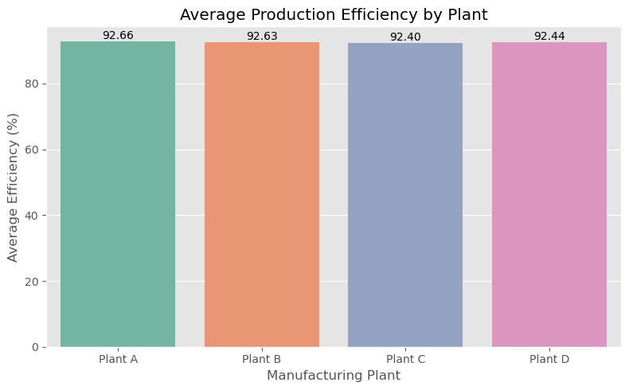

```python
plt.figure(figsize=(8,5))

ax = sns.barplot(
    data=plant_efficiency,
    x='Plant',
    y='Efficiency',
    palette='Set2'
)

plt.title("Average Production Efficiency by Plant")
plt.xlabel("Manufacturing Plant")
plt.ylabel("Average Efficiency (%)")

# Value Labels
for container in ax.containers:
    ax.bar_label(container, fmt='%.2f', fontsize=10)

plt.tight_layout()
plt.show()
```

Interpretation Example:

Plant A achieved the highest average efficiency of 92.66%, while Plant B recorded 92.63%, indicating scope for improving operational performance at Plant B.

Analysis 3: Average Production Cost by Plant

```python
plant_cost = df.groupby('Plant')['Production_Cost'].mean().reset_index()

print(plant_cost)
```

```
     Plant  Production_Cost
0  Plant A    853253.976879
1  Plant B    883036.352239
2  Plant C    881390.079710
3  Plant D    911600.818930
```

Interpretation:

The table compares the average production cost across manufacturing plants. A lower production cost combined with high efficiency generally indicates better operational performance.

Visualization: Average Production Cost by Plant

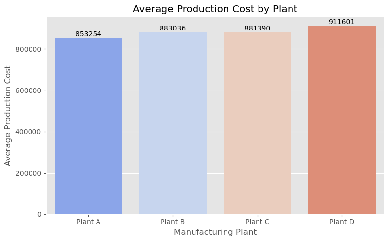

```python
plt.figure(figsize=(8,5))

ax = sns.barplot(
    data=plant_cost,
    x='Plant',
    y='Production_Cost',
    palette='coolwarm'
)

plt.title("Average Production Cost by Plant")
plt.xlabel("Manufacturing Plant")
plt.ylabel("Average Production Cost")

# Value Labels
for container in ax.containers:
    ax.bar_label(container, fmt='%.0f', fontsize=10)

plt.tight_layout()
plt.show()
```

Interpretation:

Plant D has the highest average production cost, while Plant A has the lowest. This suggests that Plant A operates more cost-effectively.

Analysis 4: Average Defect Rate by Plant

```python
plant_defect = df.groupby('Plant')['Defect_Rate'].mean().reset_index()

print(plant_defect)
```

```
     Plant  Defect_Rate
0  Plant A     0.708671
1  Plant B     1.390119
2  Plant C     2.504710
3  Plant D     4.003992
```

Interpretation:

The average defect rate indicates the quality performance of each plant. Lower defect rates reflect better manufacturing quality and process control.

Visualization: Average Defect Rate by Plant

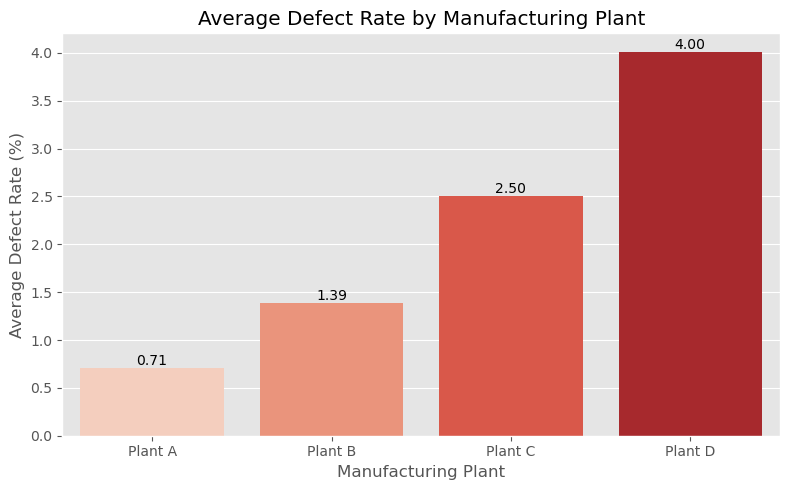

```python
plt.figure(figsize=(8,5))

ax = sns.barplot(
    data=plant_defect,
    x='Plant',
    y='Defect_Rate',
    palette='Reds'
)

plt.title("Average Defect Rate by Manufacturing Plant")
plt.xlabel("Manufacturing Plant")
plt.ylabel("Average Defect Rate (%)")

# Value Labels
for container in ax.containers:
    ax.bar_label(container, fmt='%.2f', fontsize=10)

plt.tight_layout()
plt.show()
```

Interpretation:

Plant D recorded the highest average defect rate (4.00%), whereas Plant A recorded the lowest (0.71%). Lower defect rates indicate stronger quality assurance practices.

Analysis 5: Plant-wise Sales

```python
plant_sales = df.groupby('Plant')['Sales'].sum().reset_index()

print(plant_sales)
```

```
     Plant   Sales
0  Plant A  491335
1  Plant B  425470
2  Plant C  301563
3  Plant D  220605
```

Interpretation:

The total sales by manufacturing plant help identify which plant contributes most to the company's overall revenue through vehicle sales.

Visualization: Total Sales by Plant

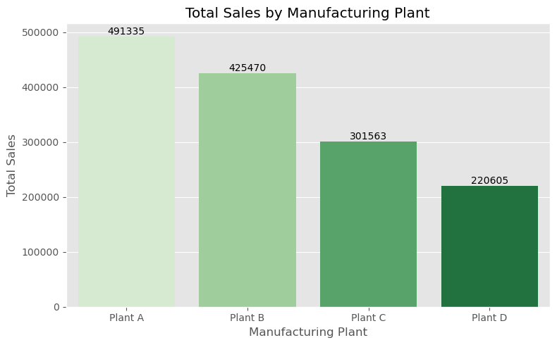

```python
plt.figure(figsize=(8,5))

ax = sns.barplot(
    data=plant_sales,
    x='Plant',
    y='Sales',
    palette='Greens'
)

plt.title("Total Sales by Manufacturing Plant")
plt.xlabel("Manufacturing Plant")
plt.ylabel("Total Sales")

# Value Labels
for container in ax.containers:
    ax.bar_label(container, fmt='%.0f', fontsize=10)

plt.tight_layout()
plt.show()
```

Interpretation

Plant A achieved the highest total sales, indicating strong production-to-sales conversion and market demand. Plants with comparatively lower sales should investigate factors such as demand forecasting and distribution efficiency.

Best Manufacturing Plant

```python
best_plant = df.groupby('Plant')[['Efficiency',
                                  'Defect_Rate',
                                  'Sales',
                                  'Units_Produced']].mean()

print(best_plant)
```

```
         Efficiency  Defect_Rate        Sales  Units_Produced
Plant
Plant A   92.660549     0.708671  1420.043353     1532.410405
Plant B   92.632299     1.390119  1270.059701     1371.101493
Plant C   92.403152     2.504710  1092.619565     1182.391304
Plant D   92.444486     4.003992   907.839506      981.860082
```

Business Insight

Based on the combined analysis of production, efficiency, defect rate, and sales, Plant A is identified as the best-performing manufacturing plant. It demonstrates high production efficiency, strong sales performance, and a relatively low defect rate, making it a benchmark for other plants.

Recommendations:

-> Adopt the production practices of the highest-performing plant across all manufacturing facilities.

-> Reduce production costs without compromising product quality.

-> Increase preventive maintenance to minimize defects and improve equipment reliability.

-> Strengthen quality inspections in plants with higher defect rates.

-> Monitor production efficiency regularly using performance dashboards.

3. Vehicle Category Performance Analysis

Analysis 1: Average Units Produced by Vehicle Category

```python
# Average Units Produced

vehicle_production = df.groupby('Vehicle_Type')['Units_Produced'].mean().reset_index()

print(vehicle_production)
```

```
         Vehicle_Type  Units_Produced
0  Commercial Vehicle     1280.157143
1   Passenger Vehicle     1301.658824
```

Interpretation:

The table shows the average number of units produced for Passenger Vehicles (PV) and Commercial Vehicles (CV). The category with the higher average production contributes more significantly to the company's manufacturing operations.

Visualization: Average Units Produced

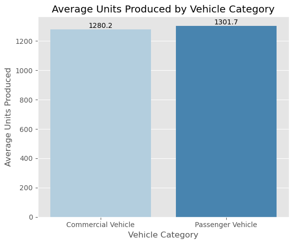

```python
plt.figure(figsize=(6,5))

ax = sns.barplot(
    data=vehicle_production,
    x='Vehicle_Type',
    y='Units_Produced',
    palette='Blues'
)

plt.title("Average Units Produced by Vehicle Category")
plt.xlabel("Vehicle Category")
plt.ylabel("Average Units Produced")

for container in ax.containers:
    ax.bar_label(container, fmt='%.1f', fontsize=10)

plt.tight_layout()
plt.show()
```

Interpretation:

Passenger Vehicles produced an average of 1301 units, while Commercial Vehicles produced 1280 units. This indicates that the company allocates more production capacity to the category with the higher value.

Analysis 2: Average Sales by Vehicle Category

```python
vehicle_sales = df.groupby('Vehicle_Type')['Sales'].mean().reset_index()

print(vehicle_sales)
```

```
         Vehicle_Type        Sales
0  Commercial Vehicle  1186.005714
1   Passenger Vehicle  1204.554118
```

Interpretation: The average sales comparison helps determine which vehicle category performs better in the market.

Visualization: Average Sales

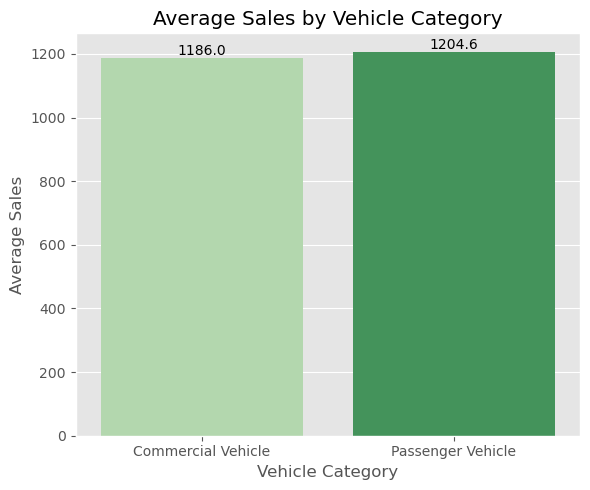

```python
plt.figure(figsize=(6,5))

ax = sns.barplot(
    data=vehicle_sales,
    x='Vehicle_Type',
    y='Sales',
    palette='Greens'
)

plt.title("Average Sales by Vehicle Category")
plt.xlabel("Vehicle Category")
plt.ylabel("Average Sales")

for container in ax.containers:
    ax.bar_label(container, fmt='%.1f', fontsize=10)

plt.tight_layout()
plt.show()
```

Interpretation:

Passenger Vehicles achieved average sales of 1204 units, whereas Commercial Vehicles achieved 1186 units. Higher sales indicate stronger customer demand for that vehicle category.

Analysis 3: Average Defects by Vehicle Category

```python
vehicle_defects = df.groupby('Vehicle_Type')['Defects'].mean().reset_index()

print(vehicle_defects)
```

```
         Vehicle_Type    Defects
0  Commercial Vehicle  24.068571
1   Passenger Vehicle  22.905882
```

Interpretation:

This analysis compares the average number of defective vehicles produced in each category.

Visualization: Average Defects

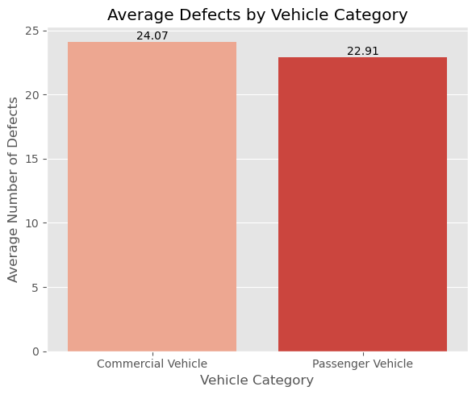

```python
plt.figure(figsize=(6,5))

ax = sns.barplot(
    data=vehicle_defects,
    x='Vehicle_Type',
    y='Defects',
    palette='Reds'
)

plt.title("Average Defects by Vehicle Category")
plt.xlabel("Vehicle Category")
plt.ylabel("Average Number of Defects")

for container in ax.containers:
    ax.bar_label(container, fmt='%.2f', fontsize=10)

plt.tight_layout()
plt.show()
```

Interpretation:

Commercial Vehicles recorded an average of 24.07 defects compared to 22.91 for Passenger Vehicles. A lower defect count indicates better manufacturing quality.

Analysis 4: Average Defect Rate by Vehicle Category

```python
vehicle_defect_rate = df.groupby('Vehicle_Type')['Defect_Rate'].mean().reset_index()

print(vehicle_defect_rate)
```

```
         Vehicle_Type  Defect_Rate
0  Commercial Vehicle     2.082714
1   Passenger Vehicle     1.936718
```

Interpretation: Defect rate measures the percentage of defective vehicles produced in each category.

Visualization: Average Defect Rate

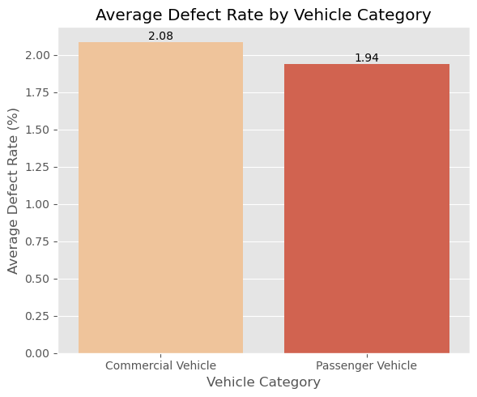

```python
plt.figure(figsize=(6,5))

ax = sns.barplot(
    data=vehicle_defect_rate,
    x='Vehicle_Type',
    y='Defect_Rate',
    palette='OrRd'
)

plt.title("Average Defect Rate by Vehicle Category")
plt.xlabel("Vehicle Category")
plt.ylabel("Average Defect Rate (%)")

for container in ax.containers:
    ax.bar_label(container, fmt='%.2f', fontsize=10)

plt.tight_layout()
plt.show()
```

Interpretation:

Passenger Vehicles recorded an average defect rate of 1.94%, while Commercial Vehicles recorded 2.08%. The lower defect rate indicates superior production quality.

Analysis 5: Average Warranty Claims

```python
vehicle_warranty = df.groupby('Vehicle_Type')['Warranty_Claims'].mean().reset_index()

print(vehicle_warranty)
```

```
         Vehicle_Type  Warranty_Claims
0  Commercial Vehicle        13.768571
1   Passenger Vehicle        12.681176
```

Interpretation:

Warranty claims represent customer-reported product issues after purchase. Lower warranty claims generally indicate higher product reliability.

Visualization: Average Warranty Claims

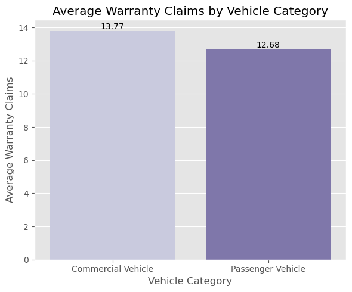

```python
plt.figure(figsize=(6,5))

ax = sns.barplot(
    data=vehicle_warranty,
    x='Vehicle_Type',
    y='Warranty_Claims',
    palette='Purples'
)

plt.title("Average Warranty Claims by Vehicle Category")
plt.xlabel("Vehicle Category")
plt.ylabel("Average Warranty Claims")

for container in ax.containers:
    ax.bar_label(container, fmt='%.2f', fontsize=10)

plt.tight_layout()
plt.show()
```

Interpretation:

Passenger Vehicles recorded 12.68 average warranty claims compared to 13.77 for Commercial Vehicles. Lower warranty claims suggest better customer satisfaction and product durability.

Analysis 6: Average Production Efficiency

```python
vehicle_efficiency = df.groupby('Vehicle_Type')['Efficiency'].mean().reset_index()

print(vehicle_efficiency)
```

```
         Vehicle_Type  Efficiency
0  Commercial Vehicle   92.578429
1   Passenger Vehicle   92.537882
```

Interpretation:

This analysis compares the average production efficiency of Passenger Vehicles and Commercial Vehicles.

Visualization: Average Production Efficiency

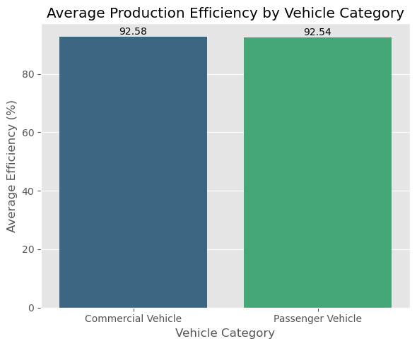

```python
plt.figure(figsize=(6,5))

ax = sns.barplot(
    data=vehicle_efficiency,
    x='Vehicle_Type',
    y='Efficiency',
    palette='viridis'
)

plt.title("Average Production Efficiency by Vehicle Category")
plt.xlabel("Vehicle Category")
plt.ylabel("Average Efficiency (%)")

for container in ax.containers:
    ax.bar_label(container, fmt='%.2f', fontsize=10)

plt.tight_layout()
plt.show()
```

Interpretation:

Passenger Vehicles achieved an average production efficiency of 92.54%, while Commercial Vehicles achieved 92.58%. The higher efficiency reflects more effective resource utilization during manufacturing.

Combined Performance Summary

```python
vehicle_summary = df.groupby('Vehicle_Type')[
    ['Units_Produced',
     'Sales',
     'Defects',
     'Defect_Rate',
     'Warranty_Claims',
     'Efficiency']
].mean().round(2)

print(vehicle_summary)
```

```
                    Units_Produced    Sales  Defects  Defect_Rate  \
Vehicle_Type
Commercial Vehicle         1280.16  1186.01    24.07         2.08
Passenger Vehicle          1301.66  1204.55    22.91         1.94

                    Warranty_Claims  Efficiency
Vehicle_Type
Commercial Vehicle            13.77       92.58
Passenger Vehicle             12.68       92.54
```

Business Insight:

4. Quality Analysis

Analysis 1: Production Cost vs Defect Rate

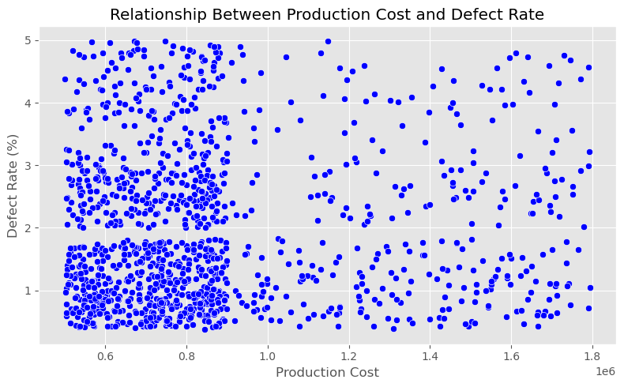

```python
# Scatter Plot - Production Cost vs Defect Rate

plt.figure(figsize=(8,5))

sns.scatterplot(
    data=df,
    x='Production_Cost',
    y='Defect_Rate',
    color='blue'
)

plt.title("Relationship Between Production Cost and Defect Rate")
plt.xlabel("Production Cost")
plt.ylabel("Defect Rate (%)")

plt.tight_layout()
plt.show()
```

Correlation Value

```python
# Correlation

correlation = df['Production_Cost'].corr(df['Defect_Rate'])

print("Correlation between Production Cost and Defect Rate:", round(correlation,3))
```

```
Correlation between Production Cost and Defect Rate: 0.051
```

Interpretation:

The correlation coefficient between Production Cost and Defect Rate is 0.051, indicating a very weak positive relationship. This suggests that changes in production cost have almost no significant impact on the defect rate. In other words, increasing or decreasing production cost does not substantially affect the number of defects. Therefore, other factors such as production processes, machine maintenance, employee skills, and quality control measures are likely to have a greater influence on product quality.

Business Insight:

Since the correlation is very weak (0.051), AutoDrive Motors Ltd. should focus on improving manufacturing processes, quality inspections, and preventive maintenance rather than simply increasing production costs to reduce defects.

Analysis 2: Inspection Score Across Plants

```python
plant_inspection = df.groupby('Plant')['Inspection_Score'].mean().reset_index()

print(plant_inspection)
```

```
     Plant  Inspection_Score
0  Plant A         96.468208
1  Plant B         92.343284
2  Plant C         86.942029
3  Plant D         79.971193
```

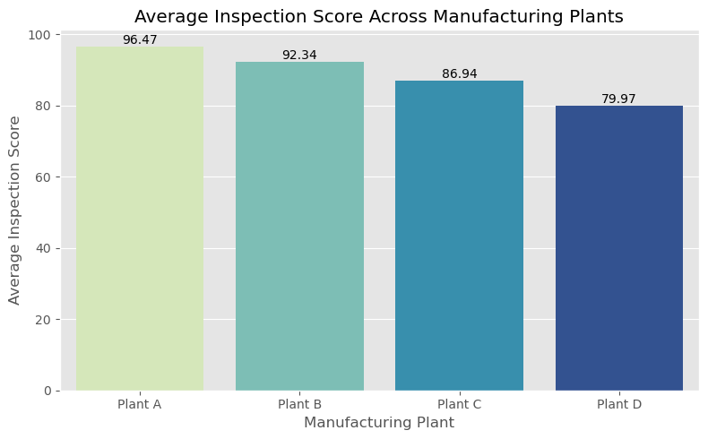

```python
plt.figure(figsize=(8,5))

ax = sns.barplot(
    data=plant_inspection,
    x='Plant',
    y='Inspection_Score',
    palette='YlGnBu'
)

plt.title("Average Inspection Score Across Manufacturing Plants")
plt.xlabel("Manufacturing Plant")
plt.ylabel("Average Inspection Score")

for container in ax.containers:
    ax.bar_label(container, fmt='%.2f', fontsize=10)

plt.tight_layout()
plt.show()
```

Interpretation:

Plant A achieved an average inspection score of 96.47, which is the highest among all plants. This indicates stronger quality control practices.

Analysis 3: Inspection Score Distribution

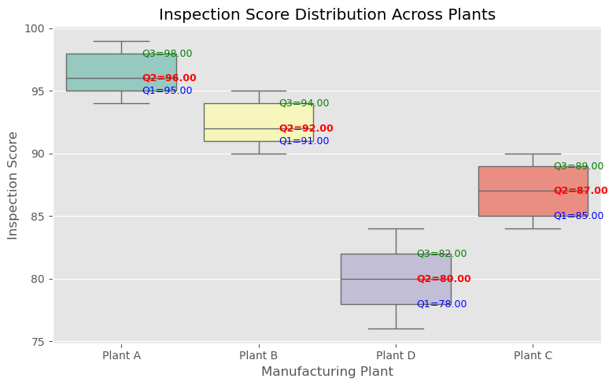

```python
plt.figure(figsize=(8,5))

ax = sns.boxplot(
    data=df,
    x='Plant',
    y='Inspection_Score',
    palette='Set3'
)

plt.title("Inspection Score Distribution Across Plants")
plt.xlabel("Manufacturing Plant")
plt.ylabel("Inspection Score")

# Get plants in the same order as the plot
plants = df['Plant'].unique()

# Add Q1, Median (Q2), and Q3 labels
for i, plant in enumerate(plants):
    q1 = df[df['Plant'] == plant]['Inspection_Score'].quantile(0.25)
    q2 = df[df['Plant'] == plant]['Inspection_Score'].quantile(0.50)
    q3 = df[df['Plant'] == plant]['Inspection_Score'].quantile(0.75)

    # Q1
    ax.text(i + 0.15, q1,
            f'Q1={q1:.2f}',
            fontsize=9,
            color='blue',
            va='center')

    # Median (Q2)
    ax.text(i + 0.15, q2,
            f'Q2={q2:.2f}',
            fontsize=9,
            color='red',
            va='center',
            fontweight='bold')

    # Q3
    ax.text(i + 0.15, q3,
            f'Q3={q3:.2f}',
            fontsize=9,
            color='green',
            va='center')

plt.tight_layout()
plt.show()
```

Interpretation Plant A :achieved the highest inspection quality, with a median score of 96, indicating excellent quality control and consistent manufacturing standards.

Plant B: ranked second with a median inspection score of 92, reflecting strong quality management practices.

Plant C: recorded a median score of 87, showing satisfactory performance but with opportunities for improvement.

Plant D: had the lowest median inspection score (80), indicating comparatively weaker inspection performance and a greater need for quality enhancement initiatives.

Business Insight:

The boxplot clearly shows that Plant A is the benchmark for manufacturing quality, followed by Plant B. Plant D requires immediate attention to improve inspection procedures, employee training, equipment maintenance, and quality control processes. By adopting the best practices implemented in Plant A, the company can improve inspection scores, reduce manufacturing defects, and enhance overall production quality across all plants.

Analysis 4: Correlation Heatmap

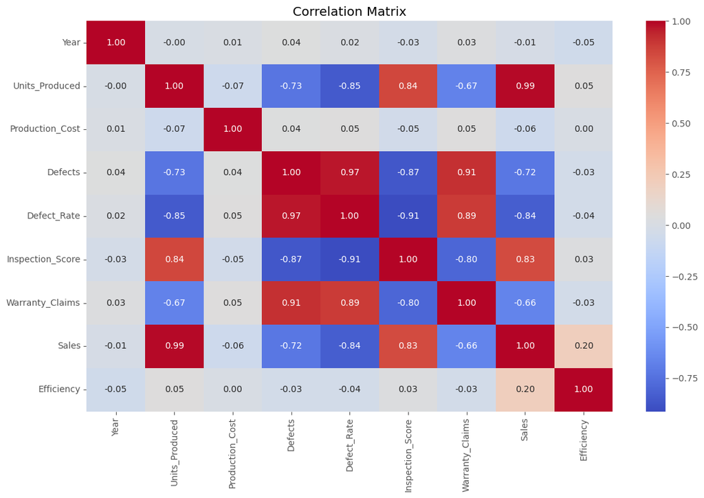

```python
plt.figure(figsize=(12,8))

sns.heatmap(
    df.corr(numeric_only=True),
    annot=True,
    cmap='coolwarm',
    fmt=".2f"
)

plt.title("Correlation Matrix")

plt.tight_layout()

plt.show()
```

Business Insight:

The correlation analysis highlights that quality control is a critical factor influencing manufacturing performance. Higher inspection scores are strongly associated with lower defect rates, fewer warranty claims, and higher sales, while increased defects lead to reduced sales and increased warranty claims. Additionally, the very strong positive correlation between Units Produced and Sales (0.99) indicates that AutoDrive Motors Ltd. effectively converts production into market sales. The company should continue strengthening inspection processes and reducing manufacturing defects to improve product quality, customer satisfaction, and overall business performance.

5. Production Trend Analysis

Monthly Production

```python
monthly_production = df.groupby(['Year','Month'])['Units_Produced'].sum().reset_index()

print(monthly_production)
```

```
    Year      Month  Units_Produced
0   2024      April           75846
1   2024     August           61227
2   2024   December           48553
3   2024   February           54278
4   2024    January           54605
5   2024       July           53147
6   2024       June           66832
7   2024      March           49683
8   2024        May           76654
9   2024   November           68919
10  2024    October           73450
11  2024  September           55594
12  2025      April           66017
13  2025     August           87687
14  2025   December           75030
15  2025   February           57546
16  2025    January           72038
17  2025       July           70986
18  2025       June           58598
19  2025      March           56608
20  2025        May           59254
21  2025   November           76151
22  2025    October           55955
23  2025  September           79807
```

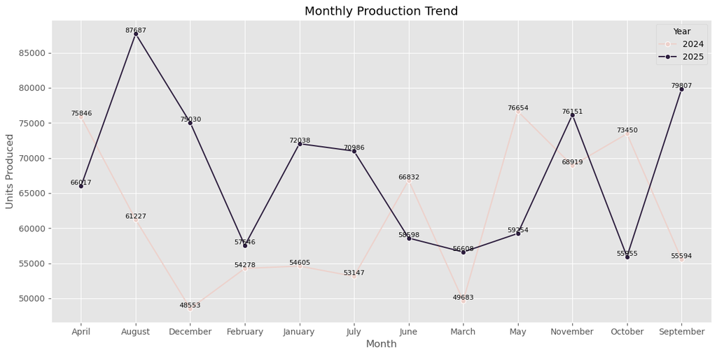

```python
plt.figure(figsize=(12,6))

ax = sns.lineplot(
    data=monthly_production,
    x='Month',
    y='Units_Produced',
    hue='Year',
    marker='o'
)

plt.title("Monthly Production Trend")
plt.xlabel("Month")
plt.ylabel("Units Produced")

# Add value labels
for line in ax.lines:
    for x, y in zip(line.get_xdata(), line.get_ydata()):
        if pd.notna(y):
            ax.text(x, y, f'{y:.0f}', fontsize=8, ha='center', va='bottom')

plt.tight_layout()
plt.show()
```

Interpretation:

The production trend illustrates monthly fluctuations over the two-year period. Months with peak production indicate higher manufacturing activity, while lower-production months may correspond to maintenance shutdowns or seasonal demand changes.

Monthly Sales Trend

```python
monthly_sales = df.groupby(['Year','Month'])['Sales'].sum().reset_index()

print(monthly_sales)
```

```
    Year      Month  Sales
0   2024      April  70035
1   2024     August  56681
2   2024   December  45111
3   2024   February  50418
4   2024    January  50397
5   2024       July  49253
6   2024       June  62006
7   2024      March  46022
8   2024        May  70872
9   2024   November  63978
10  2024    October  68383
11  2024  September  51631
12  2025      April  61332
13  2025     August  80630
14  2025   December  69248
15  2025   February  53358
16  2025    January  66296
17  2025       July  65183
18  2025       June  54443
19  2025      March  52683
20  2025        May  54684
21  2025   November  70370
22  2025    October  51866
23  2025  September  74093
```

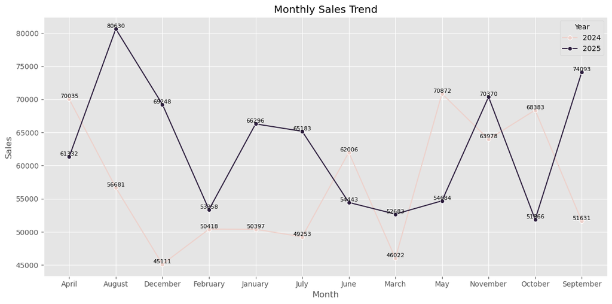

```python
plt.figure(figsize=(12,6))

ax = sns.lineplot(
    data=monthly_sales,
    x='Month',
    y='Sales',
    hue='Year',
    marker='o'
)

plt.title("Monthly Sales Trend")
plt.xlabel("Month")
plt.ylabel("Sales")

# Add value labels
for line in ax.lines:
    for x, y in zip(line.get_xdata(), line.get_ydata()):
        if pd.notna(y):
            ax.text(x, y, f'{y:.0f}', fontsize=8, ha='center', va='bottom')

plt.tight_layout()
plt.show()
```

Interpretation:

Monthly sales trends reveal periods of high and low market demand. Comparing years helps evaluate business growth and seasonal sales patterns.

Best Manufacturing Plant

```python
best_plant = df.groupby('Plant')[['Units_Produced',
                                  'Efficiency',
                                  'Defect_Rate',
                                  'Inspection_Score',
                                  'Sales']].mean().round(2)

print(best_plant)
```

```
         Units_Produced  Efficiency  Defect_Rate  Inspection_Score    Sales
Plant
Plant A         1532.41       92.66         0.71             96.47  1420.04
Plant B         1371.10       92.63         1.39             92.34  1270.06
Plant C         1182.39       92.40         2.50             86.94  1092.62
Plant D          981.86       92.44         4.00             79.97   907.84
```

Interpretation:

The analysis indicates that Plant A is the best-performing manufacturing plant, consistently outperforming the other plants in production volume, product quality, and sales. Plant A's high inspection score (96.47) and low defect rate (0.71%) contribute to its strong sales performance (1420.04 units), demonstrating an effective balance between productivity and quality.

Plant B also performs well but falls slightly behind Plant A in production and quality metrics.

Plant C shows satisfactory performance but requires improvements in quality control to reduce defects and increase sales.

Plant D requires the most attention, as it records the highest defect rate and the lowest inspection score, production, and sales. The company should prioritize quality improvement initiatives, employee training, and preventive maintenance at Plant D.

Best Vehicle Category

```python
best_vehicle = df.groupby('Vehicle_Type')[['Units_Produced',
                                           'Efficiency',
                                           'Defect_Rate',
                                           'Warranty_Claims',
                                           'Sales']].mean().round(2)

print(best_vehicle)
```

```
                    Units_Produced  Efficiency  Defect_Rate  Warranty_Claims  \
Vehicle_Type
Commercial Vehicle         1280.16       92.58         2.08            13.77
Passenger Vehicle          1301.66       92.54         1.94            12.68

                      Sales
Vehicle_Type
Commercial Vehicle  1186.01
Passenger Vehicle   1204.55
```

Best Vehicle Category Analysis:

The table compares the average performance of Commercial Vehicles (CV) and Passenger Vehicles (PV) based on Units Produced, Production Efficiency, Defect Rate, Warranty Claims, and Sales.

Commercial Vehicles (CV) Average Units Produced: 1280.16

Average Efficiency: 92.58%

Average Defect Rate: 2.08%

Average Warranty Claims: 13.77

Average Sales: 1186.01

Interpretation:

Commercial Vehicles demonstrate slightly higher production efficiency (92.58%) than Passenger Vehicles. However, they also have a higher defect rate (2.08%) and more warranty claims (13.77), indicating that quality-related issues are more frequent. Their average sales (1186.01 units) are also slightly lower than Passenger Vehicles.

Passenger Vehicles (PV) Average Units Produced: 1301.66

Average Efficiency: 92.54%

Average Defect Rate: 1.94%

Average Warranty Claims: 12.68

Average Sales: 1204.55

Interpretation:

Passenger Vehicles achieve higher average production (1301.66 units) and higher average sales (1204.55 units) compared to Commercial Vehicles. They also have a lower defect rate (1.94%) and fewer warranty claims (12.68), indicating better product quality and customer satisfaction. Although their production efficiency (92.54%) is marginally lower than Commercial Vehicles, the difference is very small and does not significantly affect overall performance.

Final conclusion

This project analyzed the manufacturing performance of AutoDrive Motors Ltd. using Python. The analysis covered data preparation, exploratory data analysis, plant-wise production performance, vehicle category comparison, quality assessment, and production trends. The findings highlighted key performance differences among manufacturing plants and vehicle categories while identifying opportunities to reduce defects, improve production efficiency, and optimize sales performance. Overall, the analysis demonstrates how data-driven decision-making can enhance manufacturing operations and support continuous improvement within the automotive industry.